# NCVS_analysis

2024-02-06

```r
library(tidyverse)
library(lattice)
library(dplyr)
```

First load DS0002 (Household Record-Type)

```r
load("/Users/itsyuzhou/Desktop/NCVS/DS0002/38429-0002-Data.rda")
load("/Users/itsyuzhou/Desktop/NCVS/DS0004/38429-0004-Data.rda")

ls()
```

```
## [1] "da38429.0002" "da38429.0004"
```

```r
household <- `da38429.0002`
incident <- `da38429.0004`
```

Inspect tables

```r
head(household)
```

```
##                  V2001  YEARQ                      IDHH V2002
## 1 (2) Household record 2021.1 1710051325461935564934133     1
## 2 (2) Household record 2021.1 1710051365368092564934132     2
## 3 (2) Household record 2021.1 1710051365448275564934213     3
## 4 (2) Household record 2021.1 1710051665447107564945132     4
## 5 (2) Household record 2021.1 1710053925458004564944133     5
## 6 (2) Household record 2021.1 1710053965345403564944112     6
##                     V2003 V2004                V2005 V2006 V2008 V2009
## 1 (211) 2021, 1st quarter    17 10051325461935564934     1    33     0
## 2 (211) 2021, 1st quarter    17 10051365368092564934     1    32     0
## 3 (211) 2021, 1st quarter    17 10051365448275564934     2    13     0
## 4 (211) 2021, 1st quarter    17 10051665447107564945     1    32     0
## 5 (211) 2021, 1st quarter    17 10053925458004564944     1    33     0
## 6 (211) 2021, 1st quarter    17 10053965345403564944     1    12     0
##                   V2010         V2011 V2012         V2013                V2014
```

[output cut: 524 more lines]

Among the household table, filter Asian household

```r
household %>% filter(!is.na(household$V2040A) & grepl("Asian", household$V2040A, ignore.case = TRUE)) %>% select(V2040A)
```

```
##                               V2040A
## 1                   (08) White-Asian
## 2                    (04) Asian only
## 3                    (04) Asian only
## 4                    (04) Asian only
## 5                    (04) Asian only
## 6                    (04) Asian only
## 7                    (04) Asian only
## 8                    (04) Asian only
## 9                    (04) Asian only
## 10                   (04) Asian only
## 11                   (04) Asian only
## 12                   (04) Asian only
## 13                   (04) Asian only
## 14                   (04) Asian only
```

[output cut: 8016 more lines]

```r
household %>%
  filter(!is.na(V2040A) & grepl("Asian", V2040A, ignore.case = TRUE)) %>%
  select(V2040A) %>%
  pull() %>%
  unique()
```

```
## [1] (08) White-Asian                (04) Asian only
## [3] (18) White-Asian-Hawaiian       (11) Black-Asian
## [5] (16) White-Black-Asian          (14) Asian-Hawaiian/Pacific Ils
## [7] (17) White-Amer Ind-Asian       (13) American Indian-Asian
## 21 Levels: (01) White only (02) Black only ... (98) Residue
```

Therefore we have the above 8 types of Asian household

```r
dim(household)
```

```
## [1] 256460    452
```

Now look at the incident table

```r
head(incident)
```

```
##                 V4001  YEARQ                      IDHH
## 1 (4) Incident record 2021.1 1710071392460695564534112
## 2 (4) Incident record 2021.1 1710071925195391564538112
## 3 (4) Incident record 2021.1 1710071925195391564538112
## 4 (4) Incident record 2021.1 1710073958381669564544133
## 5 (4) Incident record 2021.1 1710074125025301564545133
## 6 (4) Incident record 2021.1 1710074658359658564582113
##                         IDPER V4002                   V4003 V4004
## 1 171007139246069556453411201    34 (211) 2021, 1st quarter    17
## 2 171007192519539156453811201    47 (211) 2021, 1st quarter    17
## 3 171007192519539156453811201    47 (211) 2021, 1st quarter    17
## 4 171007395838166956454413301    72 (211) 2021, 1st quarter    17
## 5 171007412502530156454513306    84 (211) 2021, 1st quarter    17
## 6 171007465835965856458211301   104 (211) 2021, 1st quarter    17
##                  V4005 V4006 V4008 V4009 V4010                    V4011 V4012
```

[output cut: 1392 more lines]

V4526A - HATE CRIME: RACE

```r
table(incident$V4526A)
```

```
##
##        (1) Yes         (2) No (3) Don't know    (8) Residue
##            133             89              6             26
```

V4526C - HATE CRIME: ETHNICITY

```r
table(incident$V4526C)
```

```
##
##        (1) Yes         (2) No (3) Don't know    (8) Residue
##             77            144              7             26
```

```r
dim(incident)
```

```
## [1] 8982 1261
```

number of cases = 8,982, number of Variables = 1,261 number of race hate crime = 133, number of ethnicity hate crime = 77

```r
race_ethnicity_crime <- incident %>%
  filter(V4526A == "(1) Yes" | V4526C == "(1) Yes")

race_ethnicity_crime_count <- nrow(race_ethnicity_crime)
print(race_ethnicity_crime_count)
```

```
## [1] 146
```

So we see there are 146 hate crime incidents based on race or ethnicity among total 8982 incidents

```r
print(unique(household$YEARQ))
```

```
## [1] 2021.1 2021.2 2021.3 2021.4
```

```r
print(unique(incident$YEARQ))
```

```
## [1] 2021.1 2021.2 2021.3 2021.4
```

Visualize incident count:

```r
aggregated_race_ethnicity <- race_ethnicity_crime %>%
  group_by(YEARQ) %>%
  summarize(Count = n())

aggregated_race_ethnicity
```

```
## # A tibble: 4 × 2
##   YEARQ Count
##   <dbl> <int>
## 1 2021.    29
## 2 2021.    43
## 3 2021.    34
## 4 2021.    40
```

```r
aggregated_complete <- incident %>%
  group_by(YEARQ) %>%
  summarize(Count = n())

aggregated_complete
```

```
## # A tibble: 4 × 2
##   YEARQ Count
##   <dbl> <int>
## 1 2021.  2492
## 2 2021.  2136
## 3 2021.  2155
## 4 2021.  2199
```

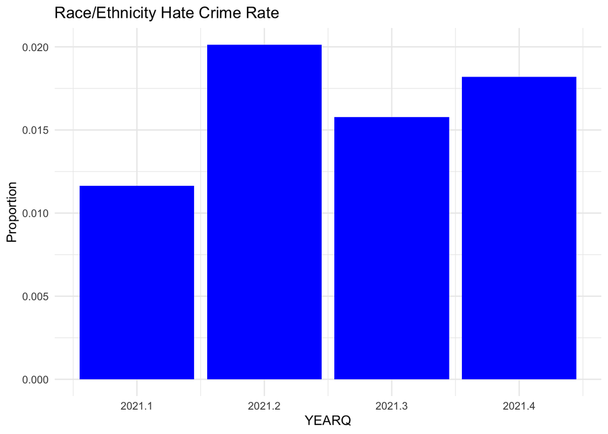

```r
aggregated_race_ethnicity$Proportion <- aggregated_race_ethnicity$Count / aggregated_complete$Count

ggplot(aggregated_race_ethnicity, aes(x = YEARQ, y = Proportion)) +
  geom_bar(stat = "identity", fill = "blue") +
  labs(x = "YEARQ", y = "Proportion") +
  ggtitle("Race/Ethnicity Hate Crime Rate") +
  theme_minimal()
```

Since the goal is examining crime incidents (victimization) while taking into consideration characteristics of the person and the household, we need to merge the household table and the incident table to obtain hate crime incidents against Asian household

- The first merges the household variables onto the person record using the YEARQ (YEAR AND QUARTER OF INTERVIEW) and IDHH (NCVS ID FOR HOUSEHOLDS) variables.

Load and store DS0003: Person Record-Type This file contains information about each household member age 12 years and older as reported by that person or proxy

```r
load("/Users/itsyuzhou/Desktop/NCVS/DS0003/38429-0003-Data.rda")
person <- `da38429.0003`
dim(person)
```

```
## [1] 291878    429
```

The household file will be used as a one-to-many match. For example, a given household record may match to several person records, and the same household information will be copied onto all of the matching person records.

```r
household_person <- merge(household, person, by = c("YEARQ", "IDHH"))
```

```r
dim(household_person)
```

```
## [1] 291878    879
```

- Second merge the first merged file with the incident record file based on YEARQ, IDHH, IDPER (the person ID)

```r
household_person_incident <- merge(household_person, incident, by = c("YEARQ", "IDHH", "IDPER"))
dim(household_person_incident)
```

```
## [1] 8982 2137
```

```r
output_file <- "/Users/itsyuzhou/Desktop/NCVS/household_person_incident.csv"
write.csv(household_person_incident, file = output_file, row.names = FALSE)
```

V4019 - CHECK ITEM D: ENOUGH DETAIL TO DISTINGUISH INCIDENTS: Can you (respondent) recall enough details of each incident to distinguish them from each other? V4022 == 1 indicates outside U.S. V4022 - IN WHAT CITY, TOWN, VILLAGE: In what city, town, or village did this incident occur? V4019==2 indicates has no enough information about the incident

```r
filtered_table <- household_person_incident %>%
  filter(!(V4019 == 2 | is.na(V4019)) & !(V4022 == 1 | is.na(V4022)))
```

```r
dim(filtered_table)
```

```
## [1]  153 2137
```

```r
dim(household_person_incident)
```

```
## [1] 8982 2137
```

Now filter race/ethnicity hate crimes

```r
race_ethnicity_crime1 <- household_person_incident %>%
  filter(V4526A == "(1) Yes" | V4526C == "(1) Yes")

race_ethnicity_crime_count1 <- nrow(race_ethnicity_crime1)
print(race_ethnicity_crime_count1)
```

```
## [1] 146
```

```r
asian_race_ethnicity <- household_person_incident %>%
  filter(grepl("Asian", V2040A, ignore.case = TRUE) & (V4526A == "(1) Yes" | V4526C == "(1) Yes"))
```

```r
dim(asian_race_ethnicity)
```

```
## [1]   17 2137
```

Among hate crimes based on race or ethnicity, check how many are Asian household

```r
race_ethnicity_crime1 %>% filter(!is.na(race_ethnicity_crime1$V2040A) & grepl("Asian", race_ethnicity_crime1$V2040A, ignore.case = TRUE)) %>% select(V2040A)
```

```
##              V2040A
## 1   (04) Asian only
## 2   (04) Asian only
## 3   (04) Asian only
## 4   (04) Asian only
## 5   (04) Asian only
## 6   (04) Asian only
## 7  (08) White-Asian
## 8   (04) Asian only
## 9   (04) Asian only
## 10  (04) Asian only
## 11  (04) Asian only
## 12  (04) Asian only
## 13  (04) Asian only
## 14  (04) Asian only
## 15  (04) Asian only
## 16  (04) Asian only
## 17  (04) Asian only
```

Total 17 cases of Asian-based race/ethnicity hate crimes, 16 of which are Asian only household, 1 is White-Asian household

```r
household_person_incident %>% filter(!is.na(household_person_incident$V2040A) & grepl("Asian", household_person_incident$V2040A, ignore.case = TRUE)) %>% select(V2040A)
```

```
##                              V2040A
## 1                  (08) White-Asian
## 2                   (04) Asian only
## 3                  (08) White-Asian
## 4                  (08) White-Asian
## 5                  (08) White-Asian
## 6                   (04) Asian only
## 7                   (04) Asian only
## 8                   (04) Asian only
## 9                   (04) Asian only
## 10                  (04) Asian only
## 11                  (04) Asian only
## 12                  (04) Asian only
## 13                  (04) Asian only
## 14                  (04) Asian only
```

[output cut: 442 more lines]

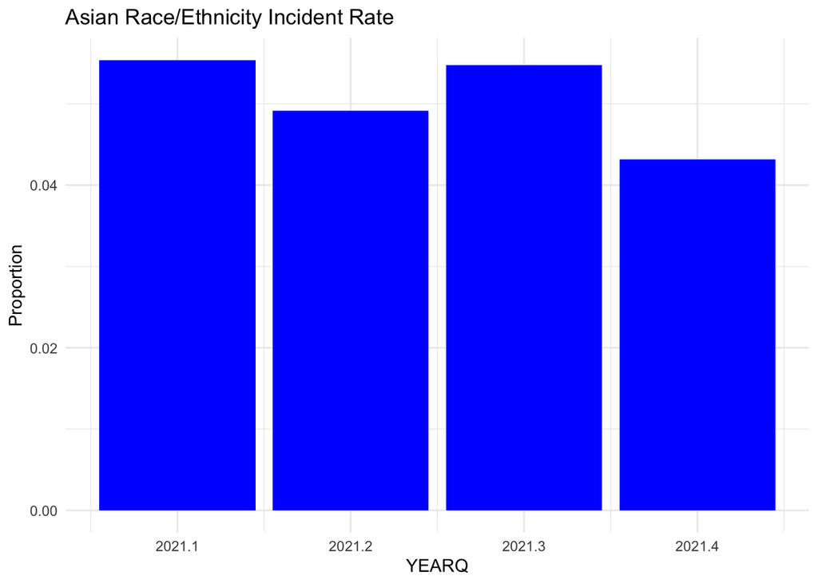

```r
asian_incident <- household_person_incident %>%
  filter(!is.na(V2040A) & grepl("Asian", V2040A, ignore.case = TRUE))

aggregated_asian_incident <- asian_incident %>%
  group_by(YEARQ) %>%
  summarize(Count = n())

aggregated_asian_incident$Proportion <- aggregated_asian_incident$Count / aggregated_complete$Count

ggplot(aggregated_asian_incident, aes(x = YEARQ, y = Proportion)) +
  geom_bar(stat = "identity", fill = "blue") +
  labs(x = "YEARQ", y = "Proportion") +
  ggtitle("Asian Race/Ethnicity Incident Rate") +
  theme_minimal()
```

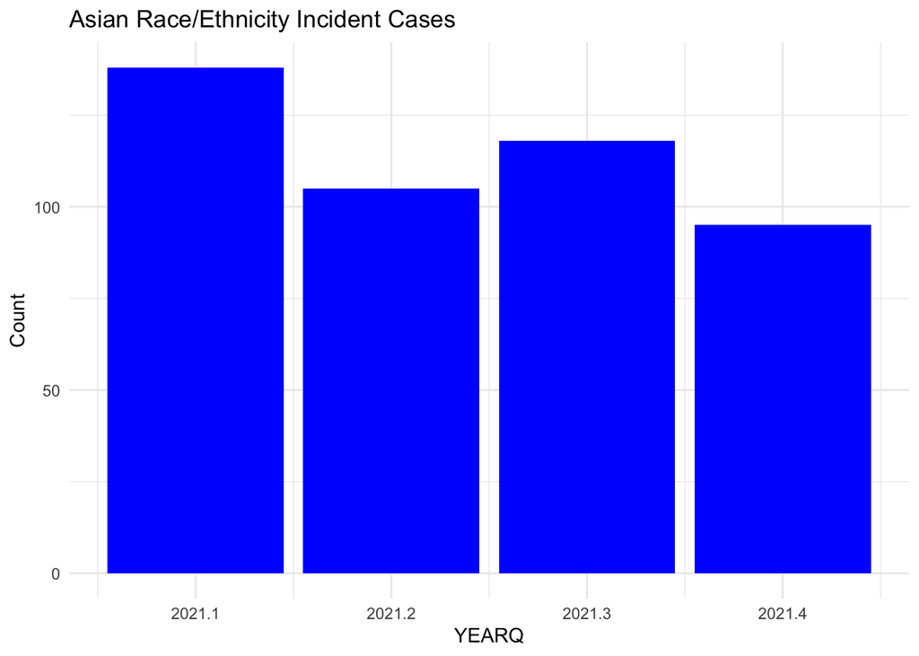

```r
ggplot(aggregated_asian_incident, aes(x = YEARQ, y = Count)) +
  geom_bar(stat = "identity", fill = "blue") +
  labs(x = "YEARQ", y = "Count") +
  ggtitle("Asian Race/Ethnicity Incident Cases") +
  theme_minimal()
```